# A3: Incarceration

### Introduction

In the Incarceration Project, I will analyze how racism exists in the prisons system in the United States from a few latitudes. Next, I will analyze 1. how the Prison population rate has changed from 1990 to 2018 for 5 randomly selected States. 2. a comparison of the population rate of each race in the United States according to the dataset I selected. 3. a map of the United States that exposes how each state in the United States ranks in terms of Prison population rate for each state in the U.S. The reason I chose these variables is to examine how geographic location (racial composition) affects prison population rate.

### Summary Information

1. Overall, how much has the black prison population rate increased? 2107143
2. Overall, how much has the white prison population rate increased? 29870
3. Which state has the largest black prison population rate? NC
4. Which state has the largest white prison population rate? NE
5. what is the average prison population rate change from 1990 to 2018? increased by 220.9582

### The Dataset

Who collected the data?

Vera Institute of Justice

How was the data collected or generated?

Vera collects data through the Bureau of Justice Statistics (BJS) Census of Jails (COJ) and Annual Survey of Jails (ASJ) through the release of the Incarceration Trends data Tool.

Why was the data collected?

The main purpose of collecting data is to study incarceration patterns in the U.S. and to study racial disparities, community influences, etc. to help inform policy makers.

How many observations (rows) are in your data?

91031 rows

How many features (columns) are in the data?

23 columns

What, if any, ethical questions or questions of power do you need to consider when working with this data?

I think there are two issues that need to be considered: 1. Data privacy. Although the data in this database are displayed in the form of regions, the personal privacy behind the data still needs to be considered. 2. Reinforced stereotypes. The use and analysis of data may potentially reinforce stereotypes and the policy-based discrimination that may result needs to be considered.

What are possible limitations or problems with this data? (at least 200 words)

1. Data coverage is not comprehensive. When completing this assignment, I noticed that certain data in many areas was “0”. This may be true, but it may also be due to a lack of information due to incomplete collection of data. This may cause problems when studying a certain area. Or inaccurate research may occur during the time period of data, which will generally affect analysis and judgment.
2. Different regions have different data collection standards due to differences in laws, enforcement, and statistics. Laws vary from state to state, making it difficult to apply uniform standards when enforcing incarceration policies. For example, one state’s laws are stricter while another is more lenient, which cannot be unified when analyzing the data. The data from each state and the process of data collection may also lead to such differences, which can lead to inaccuracies and lack of uniformity in the study data.
3. Policy changes due to time. The dataset I studied spans from 1990 to 2018. During this period, there may be changes in laws, enforcement, and statistical data standards, which is very unfavorable for studying trends caused by changes in time, which will lead to a period of investigation. The changing trend over time is affected by policy adjustments.

### Trends Over Time Chart

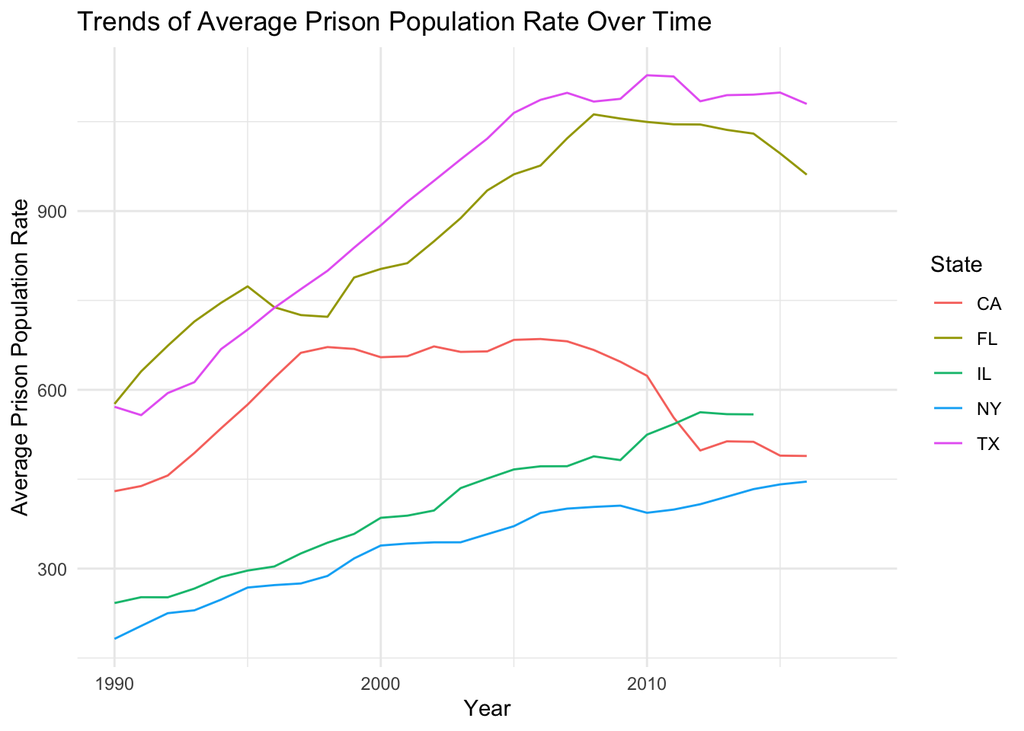

In this graph, I randomly selected 5 states, California (CA), Texas (TX), New York (NY), Florida (FL), and Illinois (IL), and showed a graph of the change in the prison population rate from 1990 to 2018. From this graph we can see that all four states except California have had significant increases in prison population rates over the 28-year period, with the two southern states, Texas and FL, having far higher crime rates than the rest of the states studied, but slowing down in the growth rate of their prison population rates around 2010, while the two northern states, NY and IL, have had a more steady rate of growth and have seen their prison population rates were lower among the five states studied. California, which had a high rate of prison population growth until 1997, had an essentially flat rate from 1997 to 2010, with a slowing trend after 2010.

### Variable Comparison Chart

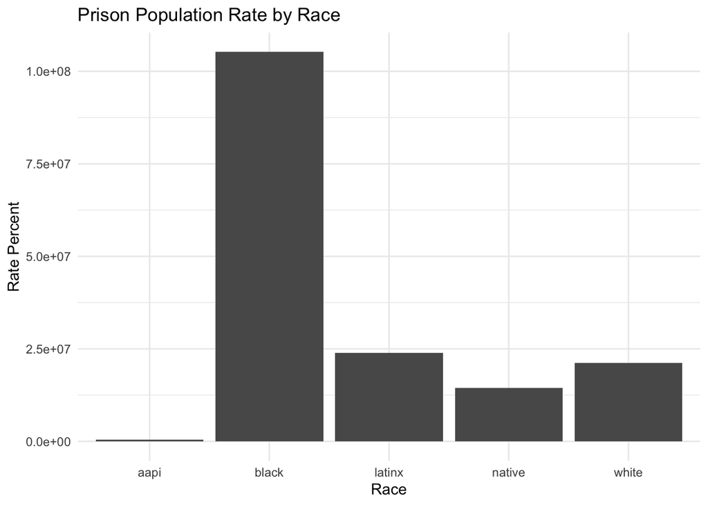

On this graph, based on the data provided in the dataset, I compared the prison population rates of five races, Black, White, Native, Latinx, and Aapi. root absolute bar graph can be seen that the prison population rates of these five races from lowest to highest are Aapi, Native, White, Latinx, and Black. By comparing the five races in the bar graph, I believe that the reasons for this disparity may include the following: 1) systematic racial discrimination in law enforcement policies and the legal system; 2) unequal distribution of social resources such as the economy, education, healthcare, and employment; and 3) unequal distribution of resources among the public and private sectors. In summary, this chart exposes the racial distribution of prison population rates.

### Map

[figure not shown]